# hwk_1

Holden Jones

2025-01-13

setup

```r
library(tidyverse)
library(effects)
bird_data <- read_csv('data/foraging.height.edit.csv')
```

```
## ──────────────────────────────────────────────────────── Delimiter: "," chr
## (6): SPECIES, Kipuka, Rat_Removal, DATE, OBSERVER, dietary.grouping dbl (6):
## ...1, Area_ha, Elevation_m, Year, tot.arth.bm, foraging.ht.m
```

# 1.

Start with some data exploration.

How many observations are there of each bird species in each experimental treatment?

```r
bird_data %>%
  group_by(SPECIES, Rat_Removal) %>%
  summarize(count = n())
```

```
## # A tibble: 12 × 3
## # Groups:   SPECIES [6]
##    SPECIES Rat_Removal count
##    <chr>   <chr>       <int>
##  1 APAP    treated       131
##  2 APAP    untreated     188
##  3 HAAM    treated        47
##  4 HAAM    untreated      42
##  5 HAEL    treated         2
##  6 HAEL    untreated       3
##  7 IIWI    treated        30
##  8 IIWI    untreated      43
##  9 JAWE    treated        16
## 10 JAWE    untreated       9
## 11 OMAO    treated         7
## 12 OMAO    untreated       9
```

Make a boxplot or violinplot to show the distribution of foraging heights of each bird species in each experimental treatment.

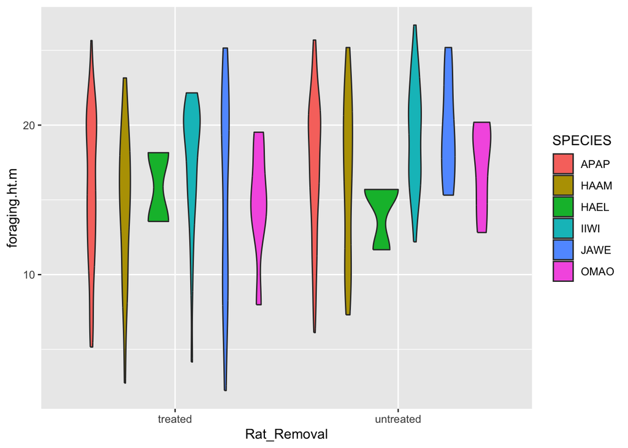

```r
ggplot(bird_data, aes(Rat_Removal, foraging.ht.m,
                 fill = SPECIES)) +
  geom_violin()
```

What have you learned so far?

# 2.

Now make a plot showing the mean foraging height of each bird species in each treatment, and include error bars displaying +/- one standard error of the mean.

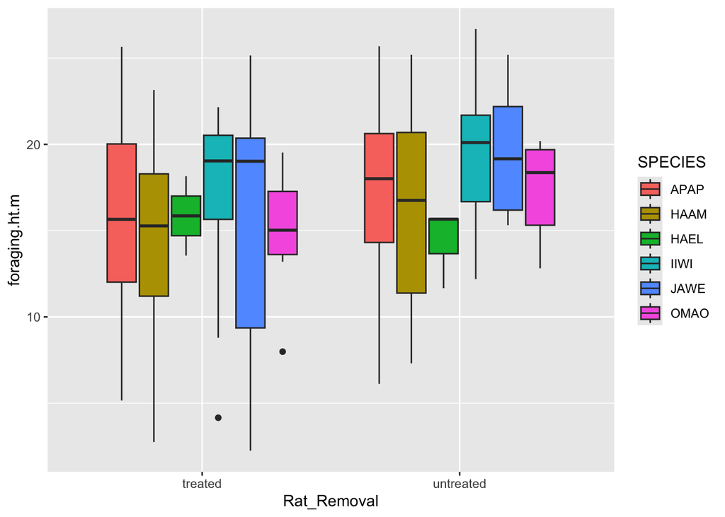

```r
ggplot(bird_data, aes(Rat_Removal, foraging.ht.m,
                 fill = SPECIES)) +
  geom_boxplot()
```

What is the meaning of the standard error of the mean? How does this plot differ from the plot in #1?

# 3.

Fit a linear model that tests whether the bird species differ in foraging height, whether the rat removal treatment affects foraging height, and whether the effect of the rat removal differs between the bird species.

```r
height_model <- lm(foraging.ht.m ~ SPECIES + Rat_Removal + Rat_Removal*SPECIES ,
            data = bird_data)
summary(height_model)
```

```
##
## Call:
## lm(formula = foraging.ht.m ~ SPECIES + Rat_Removal + Rat_Removal *
##     SPECIES, data = bird_data)
##
## Residuals:
##      Min       1Q   Median       3Q      Max
## -13.3712  -3.1989   0.4048   3.4124   9.9124
##
## Coefficients:
##                                  Estimate Std. Error t value Pr(>|t|)
## (Intercept)                       15.7426     0.4108  38.326   <2e-16 ***
## SPECIESHAAM                       -0.9253     0.7994  -1.157   0.2476
## SPECIESHAEL                        0.1124     3.3496   0.034   0.9732
## SPECIESIIWI                        1.7836     0.9516   1.874   0.0614 .
## SPECIESJAWE                       -0.1713     1.2450  -0.138   0.8906
## SPECIESOMAO                       -0.8419     1.8238  -0.462   0.6446
## Rat_Removaluntreated               1.5426     0.5351   2.883   0.0041 **
## SPECIESHAAM:Rat_Removaluntreated   0.1377     1.1326   0.122   0.9033
## SPECIESHAEL:Rat_Removaluntreated  -3.0558     4.3249  -0.707   0.4802
## SPECIESIIWI:Rat_Removaluntreated   0.2512     1.2398   0.203   0.8395
## SPECIESJAWE:Rat_Removaluntreated   2.4428     2.0306   1.203   0.2295
## SPECIESOMAO:Rat_Removaluntreated   0.7522     2.4289   0.310   0.7569
## ---
## Signif. codes:  0 '***' 0.001 '**' 0.01 '*' 0.05 '.' 0.1 ' ' 1
##
## Residual standard error: 4.701 on 515 degrees of freedom
## Multiple R-squared:  0.06603,    Adjusted R-squared:  0.04608
## F-statistic:  3.31 on 11 and 515 DF,  p-value: 0.0002061
```

Make plots to assess the distribution of the residuals.

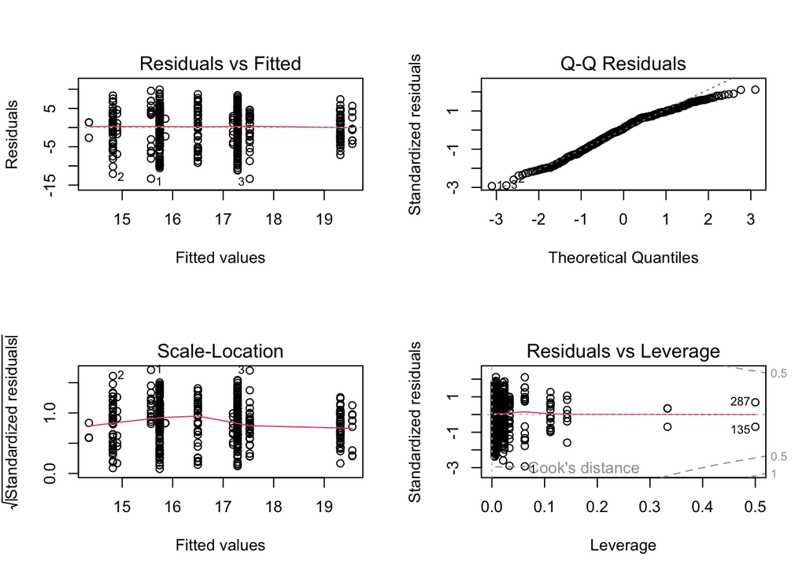

```r
par(mfrow = c(2, 2))
plot(height_model)
```

Report F-tests for the terms of the model.

```r
anova(height_model)
```

```
## Analysis of Variance Table
##
## Response: foraging.ht.m
##                      Df  Sum Sq Mean Sq F value    Pr(>F)
## SPECIES               5   386.6   77.31  3.4979  0.004051 **
## Rat_Removal           1   372.2  372.21 16.8403 4.726e-05 ***
## SPECIES:Rat_Removal   5    45.9    9.19  0.4157  0.837908
## Residuals           515 11382.8   22.10
## ---
## Signif. codes:  0 '***' 0.001 '**' 0.01 '*' 0.05 '.' 0.1 ' ' 1
```

- SPECIES, 3.50, 0.004
- Rat_Removal, 16.84, <0.001
- SPECIES*Rat_Removal, 0.42, 0.84

Create an effects plot displaying the fitted effects.

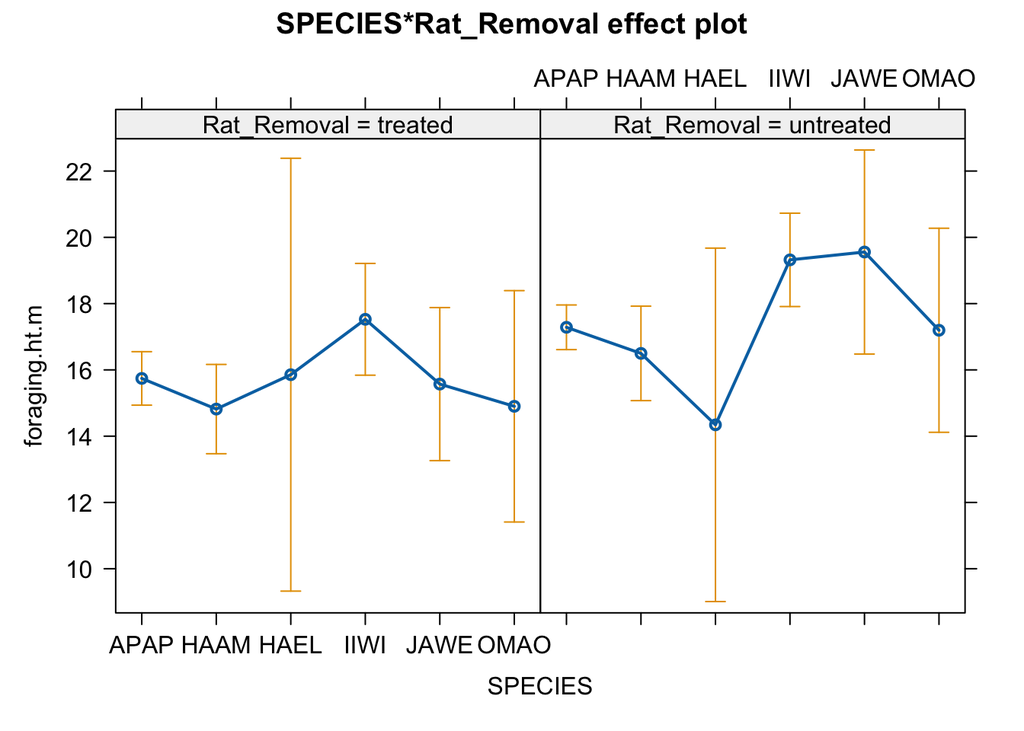

```r
plot(allEffects(height_model))
```

How do you interpret the results? What are the magnitudes of the effects?

# 4.

So far we have examined the effect of the rat removal, but we have not considered the role of kipuka size, or the role of food availability (which is influenced in part by kipuka size). Make a new model that adds kipuka area and arthopod biomass as predictors, and include interactions that test whether the treatment effect depends on these additional predictors.

```r
super_model <- lm(foraging.ht.m ~ SPECIES +
                    Rat_Removal +
                    Rat_Removal*SPECIES +
                    Area_ha +
                    tot.arth.bm +
                    Rat_Removal*Area_ha +
                    Rat_Removal*tot.arth.bm,
            data = bird_data)
summary(super_model)
```

```
##
## Call:
## lm(formula = foraging.ht.m ~ SPECIES + Rat_Removal + Rat_Removal *
##     SPECIES + Area_ha + tot.arth.bm + Rat_Removal * Area_ha +
##     Rat_Removal * tot.arth.bm, data = bird_data)
##
## Residuals:
##      Min       1Q   Median       3Q      Max
## -12.7801  -2.8938   0.2818   3.0240   8.2922
##
## Coefficients:
##                                  Estimate Std. Error t value Pr(>|t|)
## (Intercept)                      14.47586    0.45120  32.083  < 2e-16 ***
## SPECIESHAAM                      -1.07378    0.69688  -1.541  0.12398
## SPECIESHAEL                      -1.57586    2.92971  -0.538  0.59089
## SPECIESIIWI                       1.58220    0.83519   1.894  0.05874 .
## SPECIESJAWE                       0.10219    1.08609   0.094  0.92507
## SPECIESOMAO                      -0.15138    1.59596  -0.095  0.92447
## Rat_Removaluntreated             -0.48572    0.61852  -0.785  0.43264
## Area_ha                           0.44759    0.07146   6.264 7.99e-10 ***
## tot.arth.bm                      -0.03946    0.01288  -3.065  0.00229 **
## SPECIESHAAM:Rat_Removaluntreated -0.75125    0.99335  -0.756  0.44983
## SPECIESHAEL:Rat_Removaluntreated -0.91588    3.78066  -0.242  0.80868
## SPECIESIIWI:Rat_Removaluntreated -2.22866    1.11534  -1.998  0.04623 *
## SPECIESJAWE:Rat_Removaluntreated  0.97267    1.77749   0.547  0.58447
## SPECIESOMAO:Rat_Removaluntreated -0.80191    2.12606  -0.377  0.70620
## Rat_Removaluntreated:Area_ha      0.07024    0.09007   0.780  0.43584
## Rat_Removaluntreated:tot.arth.bm  0.12342    0.02863   4.311 1.95e-05 ***
## ---
## Signif. codes:  0 '***' 0.001 '**' 0.01 '*' 0.05 '.' 0.1 ' ' 1
##
## Residual standard error: 4.096 on 511 degrees of freedom
## Multiple R-squared:  0.2964, Adjusted R-squared:  0.2757
## F-statistic: 14.35 on 15 and 511 DF,  p-value: < 2.2e-16
```

Kipuka area and arthopod biomass are both continuous predictors – before you add them to the model, make some scatterplots to assess whether these predictors should be transformed when including them in the model. When assessing predictors for transformation, it doesn’t matter if the predictors are normally distributed (this only matters for the response variable) – what matters is whether the predictors are very skewed, such that a few outlying points will have a large influence on a fitted regression line. For skewed predictors, a log or square root transformation will generally help.

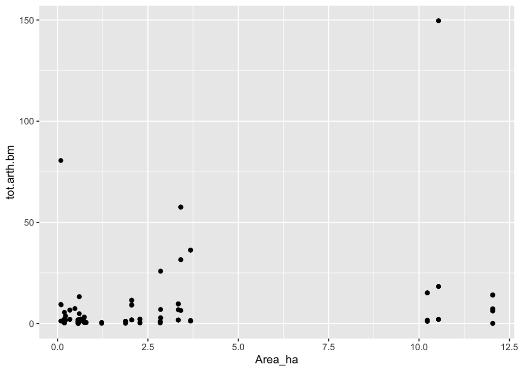

```r
ggplot(bird_data, aes(x = Area_ha, y = tot.arth.bm)) +
  geom_point()
```

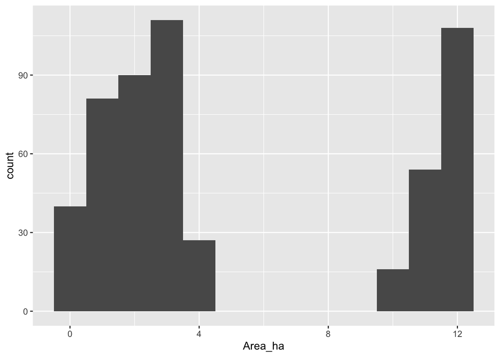

```r
# also can use individual histograms:
ggplot(bird_data, aes(x = Area_ha)) + # bimodal, not necessarily skewed
  geom_histogram(binwidth = 1)
```

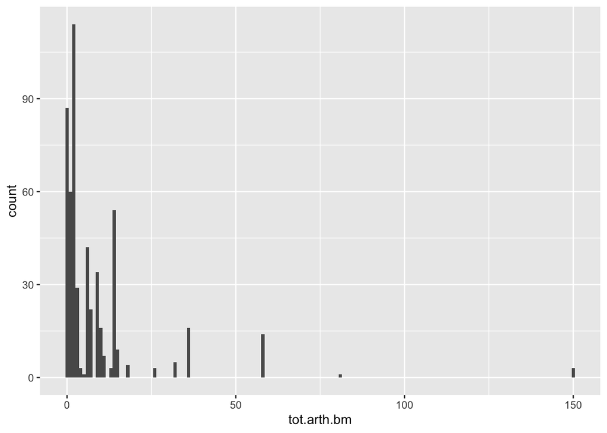

```r
ggplot(bird_data, aes(x = tot.arth.bm)) + # very skewed
  geom_histogram(binwidth = 1)
```

- tot.arth.bm looks very skewed (one point)

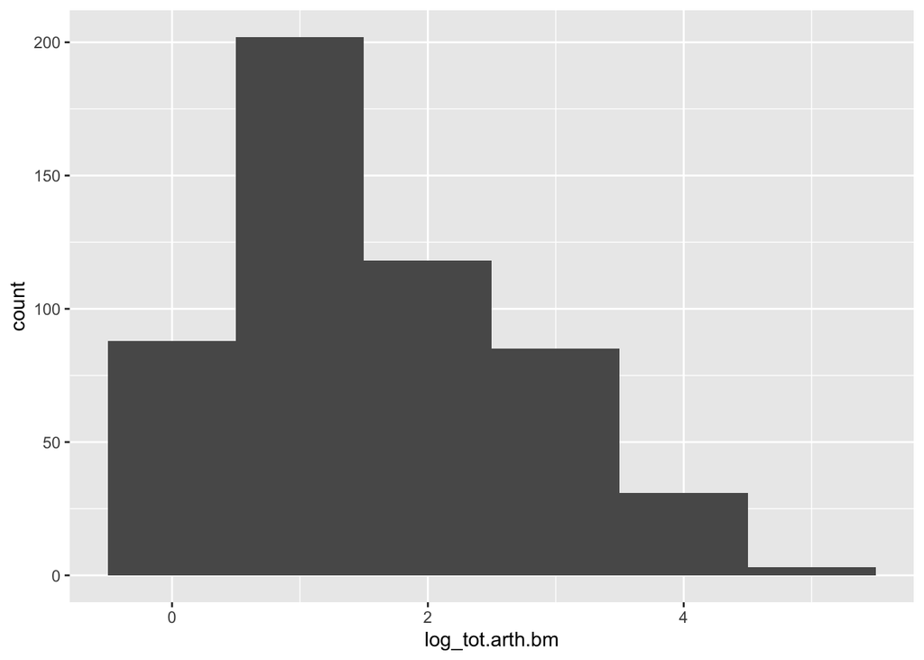

```r
# log transform tot.arth.bm
bird_data <- bird_data %>%
  mutate(log_tot.arth.bm = log(tot.arth.bm + 1))  # Adding 1 to avoid log(0)

# cool, not skewed anymore!
ggplot(bird_data, aes(x = log_tot.arth.bm)) + # very skewed
  geom_histogram(binwidth = 1)
```

Report F-tests and effects plots.

```r
log_super_model <- lm(foraging.ht.m ~ SPECIES +
                    Rat_Removal +
                    Rat_Removal*SPECIES +
                    Area_ha +
                    log_tot.arth.bm +
                    Rat_Removal*Area_ha +
                    Rat_Removal*log_tot.arth.bm,
            data = bird_data)
summary(log_super_model)
```

```
##
## Call:
## lm(formula = foraging.ht.m ~ SPECIES + Rat_Removal + Rat_Removal *
##     SPECIES + Area_ha + log_tot.arth.bm + Rat_Removal * Area_ha +
##     Rat_Removal * log_tot.arth.bm, data = bird_data)
##
## Residuals:
##      Min       1Q   Median       3Q      Max
## -16.8889  -2.7448   0.4006   3.1198   8.1793
##
## Coefficients:
##                                      Estimate Std. Error t value Pr(>|t|)
## (Intercept)                          13.65811    0.59371  23.005  < 2e-16 ***
## SPECIESHAAM                          -0.99826    0.70482  -1.416    0.157
## SPECIESHAEL                          -1.25556    2.95946  -0.424    0.672
## SPECIESIIWI                           1.20058    0.84920   1.414    0.158
## SPECIESJAWE                           0.05580    1.09894   0.051    0.960
## SPECIESOMAO                           0.02136    1.61255   0.013    0.989
## Rat_Removaluntreated                  0.11895    0.75742   0.157    0.875
## Area_ha                               0.41384    0.07181   5.763 1.43e-08 ***
## log_tot.arth.bm                       0.36358    0.26099   1.393    0.164
## SPECIESHAAM:Rat_Removaluntreated     -0.88203    1.00401  -0.879    0.380
## SPECIESHAEL:Rat_Removaluntreated     -1.22710    3.82186  -0.321    0.748
## SPECIESIIWI:Rat_Removaluntreated     -1.83854    1.13119  -1.625    0.105
## SPECIESJAWE:Rat_Removaluntreated      0.98657    1.79756   0.549    0.583
## SPECIESOMAO:Rat_Removaluntreated     -1.04153    2.14821  -0.485    0.628
## Rat_Removaluntreated:Area_ha          0.05910    0.09577   0.617    0.537
## Rat_Removaluntreated:log_tot.arth.bm  0.34954    0.37449   0.933    0.351
## ---
## Signif. codes:  0 '***' 0.001 '**' 0.01 '*' 0.05 '.' 0.1 ' ' 1
##
## Residual standard error: 4.14 on 511 degrees of freedom
## Multiple R-squared:  0.2813, Adjusted R-squared:  0.2602
## F-statistic: 13.33 on 15 and 511 DF,  p-value: < 2.2e-16
```

```r
anova(log_super_model)
```

```
## Analysis of Variance Table
##
## Response: foraging.ht.m
##                              Df Sum Sq Mean Sq  F value    Pr(>F)
## SPECIES                       5  386.6   77.31   4.5101 0.0004943 ***
## Rat_Removal                   1  372.2  372.21  21.7135 4.044e-06 ***
## Area_ha                       1 2414.8 2414.76 140.8674 < 2.2e-16 ***
## log_tot.arth.bm               1  170.7  170.65   9.9551 0.0016985 **
## SPECIES:Rat_Removal           5   54.3   10.85   0.6330 0.6746740
## Rat_Removal:Area_ha           1   14.6   14.57   0.8499 0.3570099
## Rat_Removal:log_tot.arth.bm   1   14.9   14.93   0.8712 0.3510747
## Residuals                   511 8759.6   17.14
## ---
## Signif. codes:  0 '***' 0.001 '**' 0.01 '*' 0.05 '.' 0.1 ' ' 1
```

- f-tests for each term of model above - effects plots below
- SPECIES, Rat_Removal, Area_ha, log_tot.arth.bm all highly sig terms

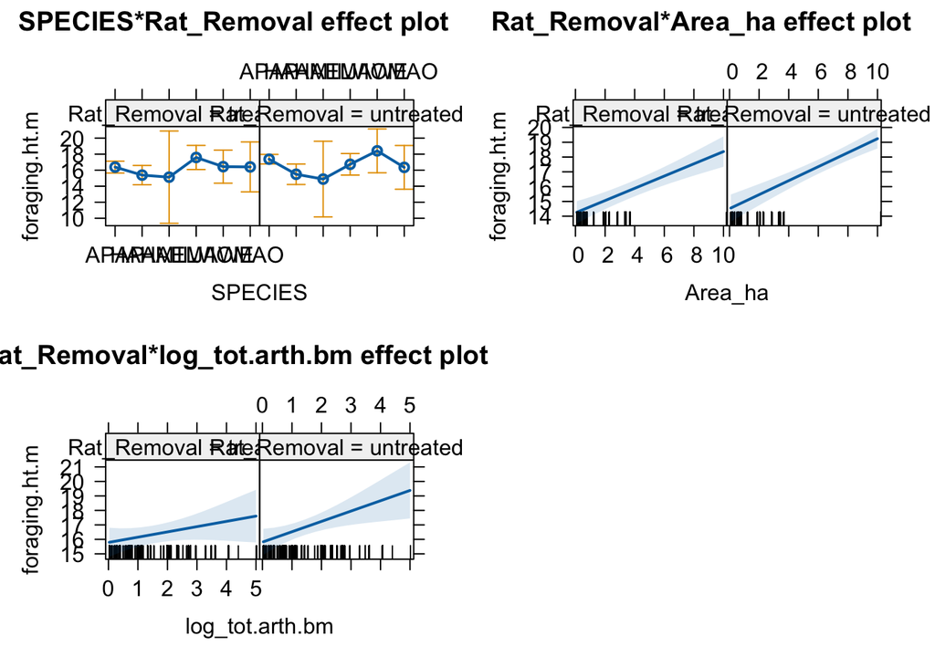

```r
plot(allEffects(log_super_model))
```

How do the results of this model differ from the model in #3?

How do you interpret the results at this stage?

- The presence of rats, the bird species, the area of the kipuka, and the biomass of arthropods all have significant effects on foraging height, but that none of the interactions between these terms are significant.

# 5.

One thing we have not accounted for in our models is the fact that the study design involves repeated measurements of the same kipuka (and potentially the same birds) over time. We will learn how to properly account for repeated measures, by adding a random effect for kipuka, later in the course. However, there is a different additional predictor that may be helpful in testing the treatment effect. Add DATE as a factor to the linear model from #4.

```r
log_super_date_model <- lm(foraging.ht.m ~ SPECIES +
                    Rat_Removal +
                    Rat_Removal*SPECIES +
                    Area_ha +
                    log_tot.arth.bm +
                    DATE +
                    Rat_Removal*Area_ha +
                    Rat_Removal*log_tot.arth.bm,
            data = bird_data)
summary(log_super_date_model)
```

```
##
## Call:
## lm(formula = foraging.ht.m ~ SPECIES + Rat_Removal + Rat_Removal *
##     SPECIES + Area_ha + log_tot.arth.bm + DATE + Rat_Removal *
##     Area_ha + Rat_Removal * log_tot.arth.bm, data = bird_data)
##
## Residuals:
##      Min       1Q   Median       3Q      Max
## -10.6977  -1.8406   0.3331   1.9175   7.0618
##
## Coefficients:
##                                       Estimate Std. Error t value Pr(>|t|)
## (Intercept)                           16.45497    0.88402  18.614  < 2e-16 ***
## SPECIESHAAM                           -1.04900    0.56299  -1.863 0.063086 .
## SPECIESHAEL                           -2.53501    2.22559  -1.139 0.255308
## SPECIESIIWI                           -0.03981    0.64531  -0.062 0.950837
## SPECIESJAWE                            2.17904    0.83678   2.604 0.009523 **
## SPECIESOMAO                           -2.18434    1.20875  -1.807 0.071425 .
## Rat_Removaluntreated                   1.44844    0.83703   1.730 0.084248 .
## Area_ha                                2.76831    0.38359   7.217 2.33e-12 ***
## log_tot.arth.bm                       -1.17636    0.27814  -4.229 2.85e-05 ***
## DATE1/13/12                            0.04652    0.90180   0.052 0.958881
## DATE1/14/12                           -9.80703    2.03119  -4.828 1.90e-06 ***
## DATE1/15/12                          -10.66334    1.90023  -5.612 3.54e-08 ***
## DATE1/16/12                           -3.99765    0.89277  -4.478 9.61e-06 ***
## DATE1/19/12                           -2.04739    1.15257  -1.776 0.076359 .
## DATE1/20/12                           -7.30089    1.00731  -7.248 1.90e-12 ***
## DATE1/21/12                           -4.03627    0.88534  -4.559 6.66e-06 ***
## DATE1/22/12                          -27.18960    3.40470  -7.986 1.22e-14 ***
## DATE1/23/12                           -4.30982    1.07615  -4.005 7.28e-05 ***
## DATE1/27/12                          -25.59078    3.51861  -7.273 1.61e-12 ***
## DATE1/28/12                           -8.61564    1.14687  -7.512 3.25e-13 ***
## DATE5/10/13                          -10.53698    1.99909  -5.271 2.13e-07 ***
## DATE5/11/13                          -10.86918    2.03789  -5.334 1.54e-07 ***
## DATE5/15/13                           -9.44233    1.15220  -8.195 2.73e-15 ***
## DATE5/16/13                           -3.43424    1.18416  -2.900 0.003916 **
## DATE5/18/13                           -9.50026    1.98353  -4.790 2.28e-06 ***
## DATE5/19/13                           -6.51951    1.04192  -6.257 9.27e-10 ***
## DATE5/23/13                           -1.82005    1.03704  -1.755 0.079944 .
## DATE5/24/13                           -4.84493    0.97069  -4.991 8.65e-07 ***
## DATE5/25/13                          -11.52959    1.30656  -8.824  < 2e-16 ***
## DATE5/27/13                          -10.58133    1.58692  -6.668 7.77e-11 ***
## DATE5/31/13                           -8.80621    3.11844  -2.824 0.004959 **
## DATE6/1/13                            -5.49545    1.19983  -4.580 6.05e-06 ***
## DATE6/2/13                            -7.23814    1.29531  -5.588 4.02e-08 ***
## DATE6/3/13                           -10.93389    1.50996  -7.241 1.99e-12 ***
## DATE6/9/13                           -13.29124    3.44453  -3.859 0.000131 ***
## SPECIESHAAM:Rat_Removaluntreated       0.25596    0.80219   0.319 0.749818
## SPECIESHAEL:Rat_Removaluntreated      -1.60365    3.16525  -0.507 0.612657
## SPECIESIIWI:Rat_Removaluntreated      -0.40869    0.85635  -0.477 0.633424
## SPECIESJAWE:Rat_Removaluntreated      -1.90495    1.34099  -1.421 0.156151
## SPECIESOMAO:Rat_Removaluntreated       1.52731    1.61501   0.946 0.344820
## Rat_Removaluntreated:Area_ha          -2.03275    0.42899  -4.738 2.91e-06 ***
## Rat_Removaluntreated:log_tot.arth.bm   3.10041    0.38302   8.095 5.62e-15 ***
## ---
## Signif. codes:  0 '***' 0.001 '**' 0.01 '*' 0.05 '.' 0.1 ' ' 1
##
## Residual standard error: 2.997 on 442 degrees of freedom
##   (43 observations deleted due to missingness)
## Multiple R-squared:  0.6475, Adjusted R-squared:  0.6147
## F-statistic:  19.8 on 41 and 442 DF,  p-value: < 2.2e-16
```

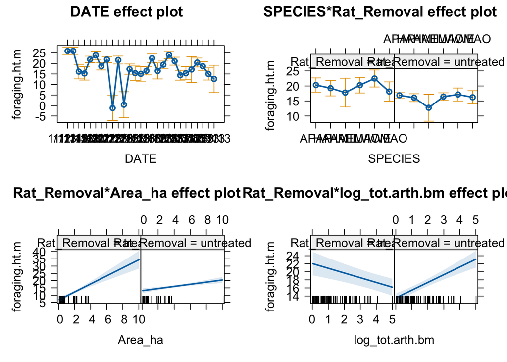

```r
plot(allEffects(log_super_date_model))
```

```r
anova(log_super_date_model)
```

```
## Analysis of Variance Table
##
## Response: foraging.ht.m
##                              Df Sum Sq Mean Sq  F value    Pr(>F)
## SPECIES                       5  428.7   85.73   9.5468 1.158e-08 ***
## Rat_Removal                   1  465.7  465.74  51.8620 2.582e-12 ***
## Area_ha                       1 1960.7 1960.74 218.3369 < 2.2e-16 ***
## log_tot.arth.bm               1  253.1  253.07  28.1806 1.753e-07 ***
## DATE                         26 3545.2  136.35  15.1837 < 2.2e-16 ***
## SPECIES:Rat_Removal           5   25.8    5.16   0.5744    0.7197
## Rat_Removal:Area_ha           1   21.9   21.93   2.4418    0.1189
## Rat_Removal:log_tot.arth.bm   1  588.4  588.42  65.5230 5.620e-15 ***
## Residuals                   442 3969.3    8.98
## ---
## Signif. codes:  0 '***' 0.001 '**' 0.01 '*' 0.05 '.' 0.1 ' ' 1
```

How does the inclusion of the date of sampling alter the model results?

- All sig effects from previous model are still sig
- Date is now sig as well, as is interaction of Rat_Removal and log_tot.arth.bm

Why do you think that is?

- tons of variation across the different dates. There are 27 unique dates, so of course there’s gonna be some with lower height foraging. But that doesn’t really tell us much. It would be perhaps more interesting to divide by season or look at month (ie so we could compare across different years). Don’t really see a clear trend in the different dates. I’m not sure why this now makes the interaction b/ween Rat_Removal and log_tot.arth.bm significant though.